# Project: Investigate a Dataset (Replace this with something more specific!)

# Data Cleaning :

#### Drop columns which are not usesful in my scope questions of analysis.

#### Handle Genres columns to split them into individules a single Genre in every row

```
    - That by generate genres_1 : genres_4 data frame and append them at the end to my data frame "df"
    - Not forget to drop any row which involve combined genres.
```

#### After fill Null in column profit using mean() function

```python
#First of All there is some arrtibutes I am not use them as feature selection to my analysis.
#Which are [ homepage ,imdb_id , production_companies ,budget_adj ,revenue_adj ]
#they are out of my scope of analysis to depend on them.
df.drop(columns=['id','homepage','imdb_id','production_companies' ,'revenue_adj' ,'budget_adj'], inplace=True)
```

```python
#From above result I cannot make a clear count for every single [genres]
# I will split the combined genres into rows and append these rows to the end of my dataset "df"

df_genres_1=df.copy()
df_genres_2=df.copy()
df_genres_3=df.copy()
df_genres_4=df.copy()
```

```python
# So I reorganize the dataset to split 'genres' with types and append them to dataset
```

```python
df_genres_1['genres']=df_genres_1['genres'].str.split("|", expand = True).apply(Series,1)[1]
df_genres_2['genres']=df_genres_2['genres'].str.split("|", expand = True).apply(Series,1)[2]
df_genres_3['genres']=df_genres_3['genres'].str.split("|", expand = True).apply(Series,1)[3]
df_genres_4['genres']=df_genres_4['genres'].str.split("|", expand = True).apply(Series,1)[4]
```

```python
# Shoud remove any tuple contain nan value in all 4 dataset
# pd.dr df_genres.genres.isnull().sum()
df_genres_1 = df_genres_1.dropna(axis=0, subset=['genres'])
df_genres_2 = df_genres_2.dropna(axis=0, subset=['genres'])
df_genres_3 = df_genres_3.dropna(axis=0, subset=['genres'])
df_genres_4 = df_genres_4.dropna(axis=0, subset=['genres'])
# df_genres_2['genres'].iloc[1].count('|')
```

```python
# Now check  df_genres.genres.isnull().sum() and the same with other
df_genres_1['genres'].isnull().sum()
```

```
0
```

```python
### Drop any row where genres contains | pipline as now we don't want it after split it into rows
df=df[~df['genres'].astype(str).str.contains(r'\|')]
```

```python
#At the end of this step we append the whole sperated genres with data frame
df = df.append([df_genres_1, df_genres_2,df_genres_3,df_genres_4],ignore_index=True)
```

```python
### Now my data frame is organized as I want in "genres"
# df.genres
df.genres.value_counts()
```

```
Drama              3020
Thriller           2510
Comedy             2186
Romance            1535
Family             1103
Science Fiction    1052
Crime               977
Horror              975
Adventure           907
Action              858
Mystery             688
Fantasy             655
Documentary         400
Music               331
Animation           328
History             291
War                 216
Foreign             180
Western             141
TV Movie             92
Name: genres, dtype: int64
```

```python
#I noticed the data type >> " release_date"  << is string

df.release_date.apply(type)[0]
```

```
str
```

```python
# Convert release_date from string to Date type
df.release_date=pd.to_datetime(df.release_date)
```

```python
#Check data type now of release_date
df['release_date'].apply(type)[0]
```

```
pandas._libs.tslibs.timestamps.Timestamp
```

```python
# df['release_date']
```

```python
df['release_month']=df['release_date'].astype(str).str.split("-", expand = True)[1]
```

```python
# df['release_month']

df['date'] = pd.to_datetime(df['release_date'])
# df['year'], df['month'] = df['date'].dt.year, df['date'].dt.month
df['year'], df['month'] = df['date'].apply(lambda x: x.year), df['date'].apply(lambda x: x.month)
```

```python
# df['release_month']=pd.to_datetime(df['release_month'])
df['keywords'].apply(type)[0]
```

```
str
```

```python
# df['benefit'].groupby('release_date').plot()

# Find the correlation of columns with revenue column

# Could I make increase revenues once I know the most revenues
# Is there a correlation between directors and the high revenues of movies
# IS the name of movie (original_title) and tagline reflect the popularity
```

```python
df.dropna(axis=0, subset=['genres'],inplace=True)
#Not care about delete rows of [   tagline , keywords ]
```

```python
df.isnull().sum()
```

```
popularity           0
budget               0
revenue              0
original_title       0
cast                92
director            66
tagline           4370
keywords          2273
overview             3
runtime              0
genres               0
release_date         0
vote_count           0
vote_average         0
release_year         0
release_month        0
date                 0
year                 0
month                0
dtype: int64
```

```python
#drop duplicate of rows to make dataset accurate for analysis
df.drop_duplicates(inplace=True)
```

```python
# Calculate new column and append it to my data frame df
# which is the profit because revenue is not representing benefits
df['profit'] =df['revenue']- df['budget']
```

```python
df['cast'].apply(type)[0]
```

```
str
```

```python
df["tagline"].fillna("No tagline", inplace = True)
df["keywords"].fillna("No keywords", inplace = True)
df["director"].fillna("No director", inplace = True)
df["director"].fillna("No director", inplace = True)
df["overview"].fillna("No cast", inplace = True)
```

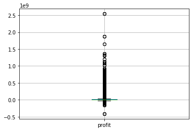

```python
# _, bp = pd.DataFrame.boxplot(df['profit'], return_type='both')
df.boxplot(column=['profit'])
```

```python
df.fillna(df.mean(), inplace=True)
```

```python
# Clean outlier
Q1 =  df['profit'].quantile(0.30)
Q3 = df['profit'].quantile(0.70)
IQR = Q3 - Q1

df['profit']=df[(df['profit'] < Q1-1.5*IQR ) | (df['profit'] > Q3+1.5*IQR)]['profit']
```

```python
df["profit"].fillna(df["profit"].mean(), inplace = True)
```

```python
# from sklearn.preprocessing import MinMaxScaler

# scaler = MinMaxScaler()
# df_scaled = pd.DataFrame(scaler.fit_transform(df['profit']), columns=df['profit'])
# df_scaled
```

```python
# df['profit'].round()
# df['col_name'] = df['col_name'].astype('int64')
df['profit'].astype('int64')
```

```
0        532330139
1        147863606
2        159564672
3         16606743
4         49191523
5        102935567
6        105795793
7         78662218
8         13623572
9         27395996
10        78662218
11       190360392
12        78662218
13        42882018
14        46163103
```

[output cut: 47 more lines]

```python
df.shape
```

```
(18441, 20)
```

```python
# 2.1 Missing Values Validation
df.isnull().sum()
```

```
popularity         0
budget             0
revenue            0
original_title     0
cast              92
director           0
tagline            0
keywords           0
overview           0
runtime            0
genres             0
release_date       0
vote_count         0
vote_average       0
release_year       0
release_month      0
date               0
year               0
month              0
profit             0
dtype: int64
```